# How do socioeconomic deprivation and physical activity levels influence the spatio-temporal patterns of pneumonia mortality across English local authorities between 2002 and 2017?

Abstract

# 1 Introduction

Pneumonia is a significant cause of mortality worldwide, despite being a preventable and treatable disease. In the United Kingdom, pneumonia causes over 25,000 deaths each year (Asthma and Lung UK 2022). Even with advances in healthcare and vaccination, pneumonia continues to impose a substantial burden on healthcare systems. Although national epidemiological studies have identified key factors associated with pneumonia mortality, such as socioeconomic status, there is a limited understanding of these associations at a local level. Socioeconomic deprivation has been recognised as a key determinant of health outcomes, with pneumonia mortality rates being approximately double in the most deprived communities in England (Office for Health Improvement and Disparities 2021). Lifestyle factors, such as decreased physical activity, have also been proposed as risk factors for pneumonia, with active individuals showing a lower risk of developing severe respiratory infections (Kunutsor, Seidu, and Laukkanen 2022). However, evidence at the local level remains limited. Using Bayesian spatio-temporal analysis, this study addresses the gap by examining geographic variation and temporal trends in pneumonia mortality across 324 English local authorities from 2002 to 2017. We employ the BYM2 spatial model to account for both structured spatial dependence and unstructured heterogeneity in pneumonia mortality patterns. The aim is to quantify local variation and trends in pneumonia mortality, and assess the impact of socioeconomic deprivation and population physical activity. We hypothesise that more deprived areas will show higher pneumonia mortality, while areas with higher physical activity levels may show lower mortality. This study intends to inform targeted public health interventions and improve health outcomes by identifying regions characterised by increased pneumonia mortality and higher deprivation.

# 2 Methods

### Statistical Modelling

Pneumonia deaths were modelled using a hierarchical Bayesian generalised linear model with a Poisson likelihood and log link function. The logarithm of the expected number of deaths was included as an offset to model standardised mortality ratios (SMRs). Let $y_{it}$ be the observed number of pneumonia deaths in local authority $i$ at year $t$, and $E_{it}$ the expected number of deaths. The model is specified as:

$$\begin{aligned}
y_{it} &\sim \text{Poisson}(\mu_{it}) \\
\log(\mu_{it}) &= \log(E_{it}) + \eta_{it} \\
\eta_{it} &= \beta_0 + \beta_1 \cdot \text{IMD}_i + \beta_2 \cdot \text{PA}_i + u_i + v_t
\end{aligned}$$
$\mu_{it}$ is the expected mean number of deaths in local authority $i$ at time $t$, $\beta_0$ is the intercept, $\beta_1$ is the regression coefficient for deprivation (IMD), $\beta_2$ is the regression coefficient for physical activity (PA), $u_i$ is the spatial random effect, $v_t$ is the temporal random effect.

### Spatial Random effects

The spatial random effect $u_i$ was modelled using the BYM2, for flexible modelling of both structured spatial dependence and unstructured heterogeneity:

$$u_i = \frac{1}{\sqrt{\tau_u}} \left( \sqrt{\phi} \cdot s_i^* + \sqrt{1 - \phi} \cdot \epsilon_i^* \right)$$

Where $s_i^*$ is the standardised structural spatial effect, $\epsilon_i^*$ is the standardised independent and identically distributed (iid) noise, $\phi$ controls the structured spatial variation, $\tau_u$ is the precision.

### Temporal Random Effects

Temporal effects $v_t$ were modelled using a first-order random walk (RW1):

$$v_t \mid v_{t-1}, \tau_v \sim \mathcal{N}(v_{t-1}, \tau_v^{-1})$$
With this model, we assume that the risk in each year is similar to the previous one, allowing for a smooth evolution of risk over time, while capturing deviations where supported by the data.

### 2.0.1 Spatio-Temporal Interaction

To allow each area to have its own temporal trajectory, Type I spatio-temporal interaction term $\delta_{it}$ was included. This model assumes an independent and identically distributed ($iid$) structure across space and time, capturing additional unstructured space and time variation. Since Type I interaction makes minimal assumptions about the data while still capturing random variations, it was chosen for the model:

$$\eta_{it} = \beta_0 + \beta_1 \cdot \text{IMD}_i + \beta_2 \cdot \text{PA}_i + u_i + v_t + \delta_{it}$$
$$\delta_{it} \sim \mathcal{N}(0, \tau_\delta^{-1})$$

Interaction was added to the adjusted model, allowing us to assess whether observed spatio-temporal variation could be explained by the covariates. All hyperparameters, including $\tau_u$, $\tau_v$, and $\phi$, were assigned penalised complexity (PC) priors, which penalise model complexity in favour of simpler structures unless strongly supported by the data.

# 3 Results

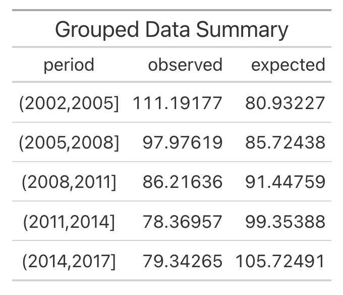

Figure 3.1: Figure showing the average observed and expected deaths across all areas for each time period

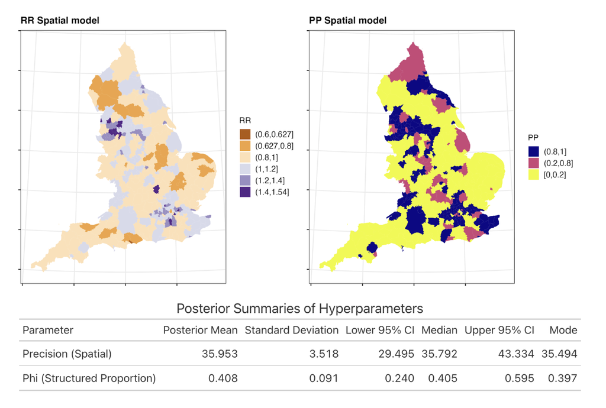

Figure 3.2: Figure highlighting the relative risks and posterior probabilities after smoothing. Note the highest relative risk spread across inland areas from London to Manchester and Liverpool.

After accounting for deprivation and physical activity (both scaled), but not allowing for area-specific time trends, the RRs show pronounced changes, with lower and higher RRs diverging further. Figure 3.3, depicts the posterior relative risks for fixed effects and shows an insignificant association between physical activity and pneumonia deaths (as indicated by the credible interval). In contrast, a one standard deviation increase in deprivation is associated with a 7.7% higher rate of pneumonia deaths (95% credible intervals exclude the null).

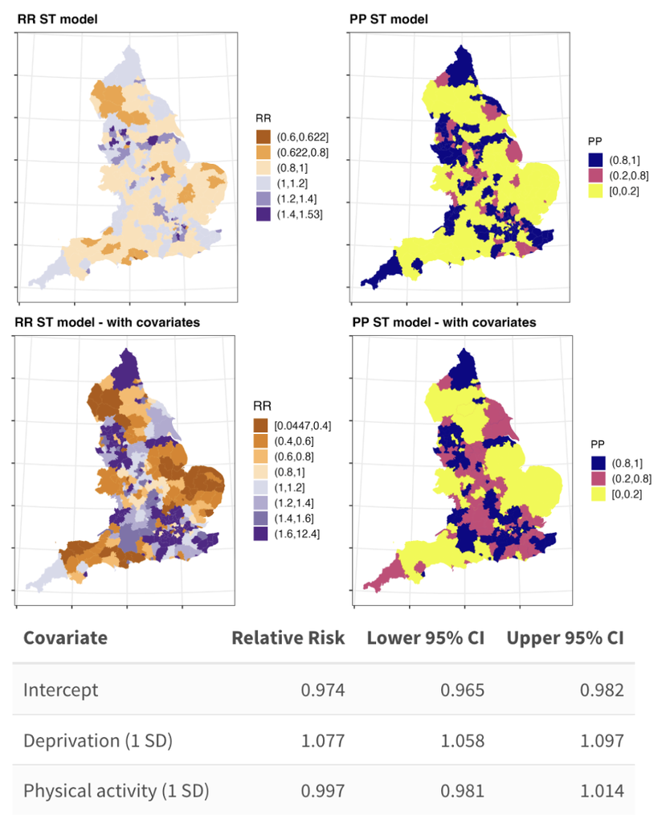

Figure 3.3: Posterior relative risks of fixed effects and the effect of covariates

Finally, the spatio-temporal models with Type I interaction further underpin the spatial and temporal characteristics highlighted thus far. Inclusion of the interaction substantially reduced the maximum estimated relative risk from approximately 12 to 1.5. The high precision values for both the models with and without covariates (34.46, 40.14) indicate low spatial variability. However, the $\phi$ values for each model indicate strong spatial correlations (76.7%, 85.1%) in the respective models. The precisions for the time components indicate a smooth temporal trend in pneumonia deaths, rather than stark changes between years. This is further reinforced in the Figure 6.1 (see appendix), depicting the smooth (and declining) temporal residual RRs across the period of study.

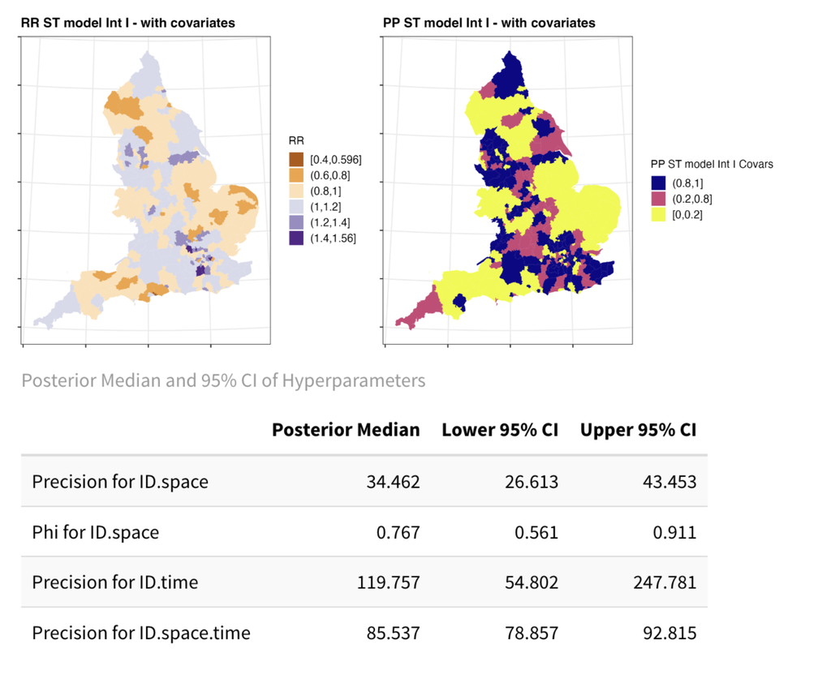

Figure 3.4: Posterior relative risks and posterior probabilities after adjusting for time and covariates.

# 4 Discussion

There are several key findings from this analysis. Firstly, pneumonia deaths have steadily decreased over time, and this trend is largely consistent across local authorities in England. This negative temporal trend is an overall improvement in pneumonia-caused mortality. Secondly, moderate to high levels of spatial structure were observed, with high spatial correlations and a substantive portion of spatial variability (40%) explained by the spatially structured component in the initial spatial model. Furthermore, consistently higher relative risks of death by pneumonia were observed in London and the North West. Inclusion of the time interaction substantially reduced the maximum estimated relative risk. This reduction suggests that much of the extreme spatial risk observed in the simpler model was an artefact of unexplained temporal variation. By modelling time-varying effects, we see more moderate risk estimates and improved model fit, suggesting our model captures different temporal trajectories in each area. Furthermore, the observed spatial autocorrelation implies that local factors beyond deprivation and physical activity might also contribute to pneumonia mortality. To summarise, consistent spatial autocorrelation (and differences) were observed across England, and the changes in these spaces were also consistent over the period of study, decreasing over time. Regarding the inclusion of covariates, deprivation was found to be associated with higher pneumonia mortality rates but not physical activity. The association of deprivation and respiratory diseases, including pneumonia, is also consistent with past literature (Hawker et al. (2003)).

# 5 Conclusion

Our research has contributed to existing literature by further refining potential areas of focus for understanding spatial temporal differences in pneumonia deaths, principally: 1) temporal trends for pneumonia are observed across space, so by looking into the factors of this decreasing trend would allow us to better approach the challenge of pneumonia (and respiratory deaths) 2) deprivation is a possible factor contributing to consistent differences in pneumonia mortality across space.

This study has several limitations. While we have highlighted the importance of temporal trends and deprivation to pneumonia mortality in the UK, it remains specific to England and the period 2002 - 2017. For validation, this study should be replicated in other countries and across more time periods. Additionally, spatial structures were defined according to local authority level, which limited our ability to capture smaller grained spatial variation and potentially masked important within area differences in pneumonia deaths. As the data is aggregated at local authority level, this analysis is restricted to the group level, excluding individual level inference in order to avoid the ecological fallacy. Finally, we only evaluated spatio-temporal models without interaction and with a Type I interaction. Given increased resources, this could be extended by investigating spatio-temporal interactions Type II-IV. Future research could investigate spatio-temporal trends of deprivation and pneumonia at a more granular geographic scale, whilst also considering additional covariates such as environmental factors which contribute to the observed variation of pneumonia deaths across space and time.

# 6 Supplementary material

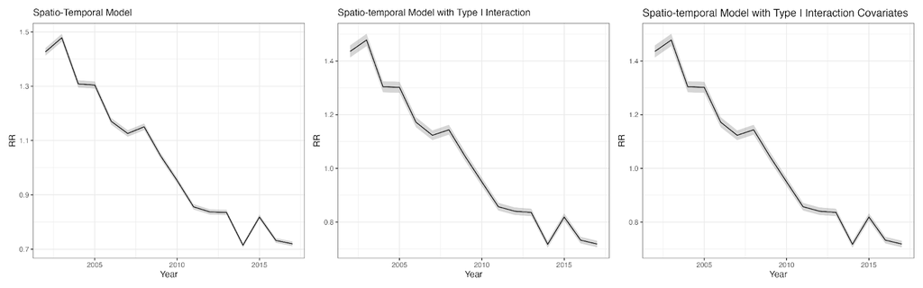

Figure 6.1: Smooth and declining trend in pneumonia mortality over time

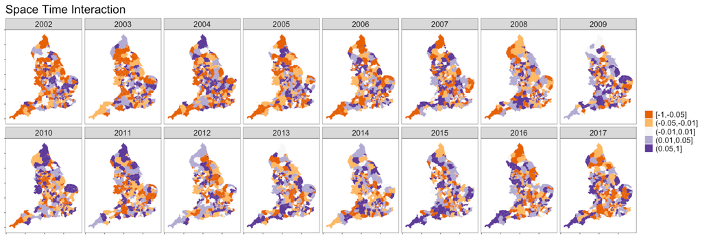

Figure 6.2: No clear pattern of space-time interaction across local authorities in period of study

# References

Asthma and Lung UK. 2022. “Asthma + Lung UK Analysis Reveals UK Has Highest Number of Pneumonia Deaths in Europe.” https://www.asthmaandlung.org.uk/media/press-releases/asthma-lung-uk-analysis-reveals-uk-has-highest-number-pneumonia-deaths-europe.

Hawker, Jeremy I, Babatunde Olowokure, Farzana Sufi, Julius Weinberg, Noel Gill, and Richard C Wilson. 2003. “Social Deprivation and Hospital Admission for Respiratory Infection:” *Respiratory Medicine* 97 (November): 1219–24. https://doi.org/10.1016/S0954-6111(03)00252-X.

Kunutsor, Setor K., Samuel Seidu, and Jari A. Laukkanen. 2022. “Physical Activity Reduces the Risk of Pneumonia: Systematic Review and Meta-Analysis of 10 Prospective Studies Involving 1,044,492 Participants.” *GeroScience* 44 (February): 519–32. https://doi.org/10.1007/s11357-021-00491-2.

Office for Health Improvement and Disparities. 2021. “Interactive Health Atlas of Lung Conditions in England (INHALE): November 2021 Update.” GOV.UK. 2021. https://www.gov.uk/government/statistics/interactive-health-atlas-of-lung-conditions-in-england-inhale-november-2021-update/interactive-health-atlas-of-lung-conditions-in-england-inhale-november-2021-update.

World Health Organization. 2024. “The Top 10 Causes of Death.” https://www.who.int/news-room/fact-sheets/detail/the-top-10-causes-of-death.